# Project 4

## Objective

For this project, I’m utilizing a dataset used in a previous study by Carnegie Melon University where different machine learning models were tested to try to find a way to discriminate between users via their typing rhythms. The main goal of that study was to find a machine learning model with low enough error rates to obtain European Union approval so that it could be used legally and with partnership from European governments. The fields in the dataset include 51 subjects, 8 sessions per subject, 50 repetitions of typing the password: ” $.tie5Roanl$“, and 31 fields for actions required to type the password. Also, this dataset simulates typing the same password multiple times(50 in this case) in a given day, represented by repetition number, and 8 days in a row, represented by session number. (Killourhy & Maxion, 2009)

I’m starting with a null hypothesis that a person’s typing dynamics change over time, short term and long term, which I’m going to attempt to reject. To do this, I will analyze the dataset via a mixed model approach. The response variable I am interested in here is total time to enter the password, while I am interested in the effects of the variables, rep which is the times the password was repeatedly typed in a day, session which is the days of the continuous repetitions of the password, and subject, which is the person typing the password. For this project, rep and session are fixed effects and subject is the nested random effect I will be testing, since rep and session are consistent actions but subject varies depending on who was available to be tested at the time. Assumptions with this dataset are that it has been cleaned and verified of any typos and entry errors.

```r
# function to install packages if they don't exist
usePackage <- function(p) {
    if (!is.element(p, installed.packages()[,1]))
        install.packages(p, dep = TRUE)
    require(p, character.only = TRUE)
}
# load packages used in this project
usePackage("readxl")
usePackage("ggplot2")
usePackage("knitr")
usePackage("formattable")
```

```
  method           from
  print.htmlwidget tools:rstudio
```

```r
usePackage("dplyr")
usePackage("tidyr")
usePackage("lme4")
usePackage("gee")
usePackage("Matrix")
usePackage("multcomp")
usePackage("car")
usePackage("MASS")
usePackage("aod")
usePackage("DT")
usePackage("broom")
#Before being able to access the file, I had to open it in Excel and save it without making any changes. Not really sure why but doing this allowed me to open the file in R to add its contents to a dataframe
PasswordData.df <- as.data.frame(read_excel("DSL-StrongPasswordData.xls", sheet="Sheet1"))


#Here took a peak at the dataset, viewing the top 6 rows and a summary of the data

head(PasswordData.df)
```

|  | subject | sessionIndex | rep | H.period | DD.period.t | UD.period.t | H.t | DD.t.i | UD.t.i | H.i | DD.i.e | UD.i.e | H.e | DD.e.five | UD.e.five | H.five | DD.five.Shift.r | UD.five.Shift.r | H.Shift.r | DD.Shift.r.o | UD.Shift.r.o | H.o | DD.o.a | UD.o.a | H.a | DD.a.n | UD.a.n | H.n | DD.n.l | … |
| --- | --- | --- | --- | --- | --- | --- | --- | --- | --- | --- | --- | --- | --- | --- | --- | --- | --- | --- | --- | --- | --- | --- | --- | --- | --- | --- | --- | --- | --- | --- |
| 1 | s002 | 1 | 1 | 0.1491 | 0.3979 | 0.2488 | 0.1069 | 0.1674 | 0.0605 | 0.1169 | 0.2212 | 0.1043 | 0.1417 | 1.1885 | 1.0468 | 0.1146 | 1.6055 | 1.4909 | 0.1067 | 0.7590 | 0.6523 | 0.1016 | 0.2136 | 0.1120 | 0.1349 | 0.1484 | 0.0135 | 0.0932 | 0.3515 | … |
| 2 | s002 | 1 | 2 | 0.1111 | 0.3451 | 0.2340 | 0.0694 | 0.1283 | 0.0589 | 0.0908 | 0.1357 | 0.0449 | 0.0829 | 1.1970 | 1.1141 | 0.0689 | 0.7822 | 0.7133 | 0.1570 | 0.7877 | 0.6307 | 0.1066 | 0.1684 | 0.0618 | 0.1412 | 0.2558 | 0.1146 | 0.1146 | 0.2642 | … |
| 3 | s002 | 1 | 3 | 0.1328 | 0.2072 | 0.0744 | 0.0731 | 0.1291 | 0.0560 | 0.0821 | 0.1542 | 0.0721 | 0.0808 | 1.0408 | 0.9600 | 0.0892 | 0.6203 | 0.5311 | 0.1454 | 0.7195 | 0.5741 | 0.1365 | 0.2931 | 0.1566 | 0.1621 | 0.2332 | 0.0711 | 0.1172 | 0.2705 | … |
| 4 | s002 | 1 | 4 | 0.1291 | 0.2515 | 0.1224 | 0.1059 | 0.2495 | 0.1436 | 0.1040 | 0.2038 | 0.0998 | 0.0900 | 1.0556 | 0.9656 | 0.0913 | 1.2564 | 1.1651 | 0.1454 | 0.7550 | 0.6096 | 0.0956 | 0.1530 | 0.0574 | 0.1457 | 0.1629 | 0.0172 | 0.0866 | 0.2341 | … |
| 5 | s002 | 1 | 5 | 0.1249 | 0.2317 | 0.1068 | 0.0895 | 0.1676 | 0.0781 | 0.0903 | 0.1589 | 0.0686 | 0.0805 | 0.8629 | 0.7824 | 0.0742 | 0.8955 | 0.8213 | 0.1243 | 0.7632 | 0.6389 | 0.0430 | 0.1975 | 0.1545 | 0.1312 | 0.1582 | 0.0270 | 0.0884 | 0.2517 | … |
| 6 | s002 | 1 | 6 | 0.1394 | 0.2343 | 0.0949 | 0.0813 | 0.1299 | 0.0486 | 0.0744 | 0.1412 | 0.0668 | 0.0863 | 0.9373 | 0.8510 | 0.0942 | 1.0896 | 0.9954 | 0.1681 | 0.3716 | 0.2035 | 0.1154 | 0.1287 | 0.0133 | 0.1272 | 0.1534 | 0.0262 | 0.0858 | 0.2528 | … |

```r
summary(PasswordData.df)
```

```
   subject           sessionIndex       rep          H.period        DD.period.t       UD.period.t           H.t              DD.t.i           UD.t.i
 Length:20400       Min.   :1.00   Min.   : 1.0   Min.   :0.00140   Min.   : 0.0187   Min.   :-0.2358   Min.   :0.00930   Min.   :0.0011   Min.   :-0.16210
 Class :character   1st Qu.:2.75   1st Qu.:13.0   1st Qu.:0.07440   1st Qu.: 0.1469   1st Qu.: 0.0498   1st Qu.:0.06600   1st Qu.:0.1136   1st Qu.: 0.02720
 Mode  :character   Median :4.50   Median :25.5   Median :0.08950   Median : 0.2059   Median : 0.1087   Median :0.08100   Median :0.1404   Median : 0.05780
                    Mean   :4.50   Mean   :25.5   Mean   :0.09338   Mean   : 0.2641   Mean   : 0.1708   Mean   :0.08573   Mean   :0.1691   Mean   : 0.08336
                    3rd Qu.:6.25   3rd Qu.:38.0   3rd Qu.:0.10790   3rd Qu.: 0.3064   3rd Qu.: 0.2124   3rd Qu.:0.09980   3rd Qu.:0.1839   3rd Qu.: 0.09640
                    Max.   :8.00   Max.   :50.0   Max.   :0.37610   Max.   :12.5061   Max.   :12.4517   Max.   :0.24110   Max.   :4.9197   Max.   : 4.79990
      H.i              DD.i.e            UD.i.e              H.e            DD.e.five        UD.e.five           H.five       DD.five.Shift.r  UD.five.Shift.r
 Min.   :0.00320   Min.   : 0.0014   Min.   :-0.16000   Min.   :0.00210   Min.   :0.0013   Min.   :-0.1505   Min.   :0.0014   Min.   :0.1694   Min.   :0.0856
 1st Qu.:0.06200   1st Qu.: 0.0893   1st Qu.: 0.00740   1st Qu.:0.06860   1st Qu.:0.2166   1st Qu.: 0.1332   1st Qu.:0.0610   1st Qu.:0.3079   1st Qu.:0.2297
 Median :0.07710   Median : 0.1209   Median : 0.04120   Median :0.08340   Median :0.2890   Median : 0.2004   Median :0.0742   Median :0.3775   Median :0.3020
 Mean   :0.08157   Mean   : 0.1594   Mean   : 0.07781   Mean   :0.08914   Mean   :0.3774   Mean   : 0.2883   Mean   :0.0769   Mean   :0.4389   Mean   :0.3620
 3rd Qu.:0.09690   3rd Qu.: 0.1731   3rd Qu.: 0.09340   3rd Qu.:0.10270   3rd Qu.:0.4568   3rd Qu.: 0.3694   3rd Qu.:0.0906   3rd Qu.:0.4860   3rd Qu.:0.4089
 Max.   :0.33120   Max.   :25.9873   Max.   :25.91580   Max.   :0.32540   Max.   :4.9618   Max.   : 4.8827   Max.   :0.1989   Max.   :8.3702   Max.   :8.2908
   H.Shift.r        DD.Shift.r.o     UD.Shift.r.o          H.o              DD.o.a           UD.o.a              H.a             DD.a.n           UD.a.n
 Min.   :0.00140   Min.   :0.0494   Min.   :-0.0865   Min.   :0.00690   Min.   :0.0012   Min.   :-0.22870   Min.   :0.0040   Min.   :0.0011   Min.   :-0.23550
 1st Qu.:0.07020   1st Qu.:0.1565   1st Qu.: 0.0547   1st Qu.:0.07150   1st Qu.:0.1064   1st Qu.: 0.01700   1st Qu.:0.0821   1st Qu.:0.0961   1st Qu.:-0.00900
 Median :0.09350   Median :0.2014   Median : 0.1022   Median :0.08630   Median :0.1316   Median : 0.04440   Median :0.1019   Median :0.1250   Median : 0.02270
 Mean   :0.09594   Mean   :0.2509   Mean   : 0.1550   Mean   :0.08835   Mean   :0.1569   Mean   : 0.06858   Mean   :0.1063   Mean   :0.1507   Mean   : 0.04441
 3rd Qu.:0.11670   3rd Qu.:0.2834   3rd Qu.: 0.1910   3rd Qu.:0.10190   3rd Qu.:0.1676   3rd Qu.: 0.08030   3rd Qu.:0.1223   3rd Qu.:0.1746   3rd Qu.: 0.06890
 Max.   :0.28170   Max.   :4.1523   Max.   : 4.0120   Max.   :0.68720   Max.   :2.8567   Max.   : 2.81520   Max.   :2.0353   Max.   :3.3278   Max.   : 2.52420
      H.n             DD.n.l           UD.n.l             H.l           DD.l.Return      UD.l.Return         H.Return
 Min.   :0.0037   Min.   :0.0013   Min.   :-0.1758   Min.   :0.00370   Min.   :0.0083   Min.   :-0.1245   Min.   :0.00290
 1st Qu.:0.0673   1st Qu.:0.1276   1st Qu.: 0.0235   1st Qu.:0.07740   1st Qu.:0.2100   1st Qu.: 0.1141   1st Qu.:0.06990
 Median :0.0853   Median :0.1725   Median : 0.0955   Median :0.09370   Median :0.2630   Median : 0.1603   Median :0.08550
 Mean   :0.0899   Mean   :0.2026   Mean   : 0.1127   Mean   :0.09559   Mean   :0.3218   Mean   : 0.2263   Mean   :0.08831
 3rd Qu.:0.1079   3rd Qu.:0.2288   3rd Qu.: 0.1457   3rd Qu.:0.11110   3rd Qu.:0.3502   3rd Qu.: 0.2551   3rd Qu.:0.10370
 Max.   :0.3577   Max.   :4.0252   Max.   : 3.9782   Max.   :0.34070   Max.   :5.8836   Max.   : 5.8364   Max.   :0.26510
```

## Exploratory Analysis

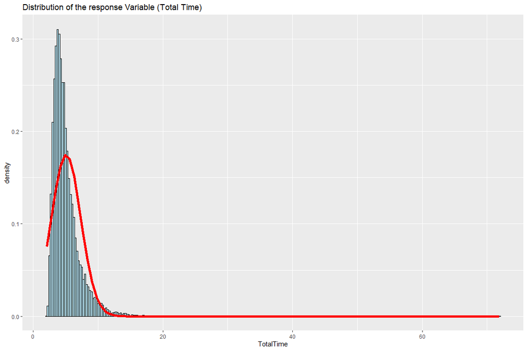

For this project, as the outliers can be attributed to the randomness of the subjects, since people often make mistakes when typing ambiguous passwords, and the data is assumed to have been cleaned and verified, I have decided not to remove outliers.

Furthermore, I decided to use penalized quasi-likelihood along with random intercept and random intercept and slope models to model the data. This technique allows for the fitting of data to mixed effect models when the data is not of a normal distribution. It is an approximate inference technique that allows estimation of model parameters without knowledge of the error distribution of the response variable. (Everitt & Hothorn, 2014) More common methods such as restricted maximum likelihood and maximum likelihood require that the data be normally distributed. (Pilowsky, 2018) Penalized quasi-likelihood just requires that the response variable not have a mean less than five and the response variable does not fit a discrete count distribution such as Poisson or Binomial, or that the response variable is not binary. (Pilowsky, 2018) The response variable’s mean is greater than 5 and is not binary so this technique should work.

Penalized Quasi-Likelihood:

$$\hat{g}_n\in \arg \max_{g\in\delta}
[\hat{Q}_n(F(g))-\lambda^2_nJ^2(g)]$$

Random intercept and random intercept and slope models are commonly used as opposed to generalized linear models for datasets with repeated measurements. (Everitt & Hothorn, 2014) These models assume that correlation amongst independent repeated measurements on the same unit arises from the shared unobserved variables and that time has a fixed effect. (Everitt & Hothorn, 2014) The difference between random intercept and random intercept and slope models are that random intercept models measure dissimilarity in intercepts while random intercept and slope models measure dissimilarity in intercepts and slopes. (Everitt & Hothorn, 2014)

Random Intercept Model:

$$y_{ij}=\beta_0 + \beta_1t_j + u_i +
\varepsilon_{ij}$$
y_ij = observation made t_j = time i = individual

Random Intercept and Slope Model:

$$y_{ij}=\beta_0 + \beta_1t_j + u_i +
v_it_j + \varepsilon_{ij}$$
u_i = intercepts v_i = slopes

*Sources:* *(Everitt & Hothorn, 2014) (Mammen & van de Gee, 1997)*

### Decide what probability distribution best fits the dataset via quantile comparison plots

```
[1] 16808 16807
```

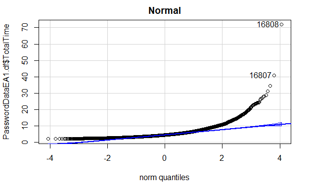

```r
# normal
qqp(PasswordDataEA1.df$TotalTime, "norm", main= "Normal")
```

```
[1] 16808 16807
```

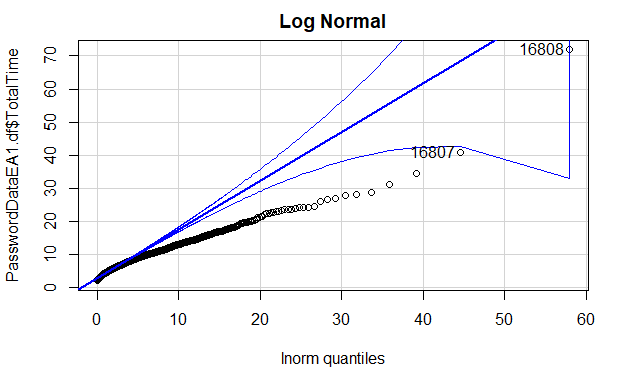

```r
# lognormal
qqp(PasswordDataEA1.df$TotalTime, "lnorm", main= "Log Normal")
```

```
[1] 16808 16807
```

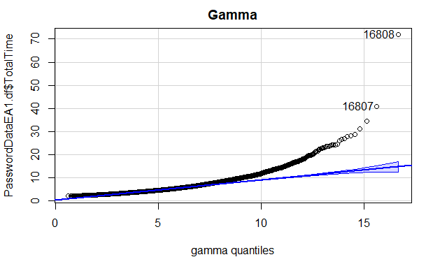

```r
# gamma
gamma <- fitdistr(PasswordDataEA1.df$TotalTime, "gamma")
qqp(PasswordDataEA1.df$TotalTime, "gamma", shape = gamma$estimate[[1]], rate = gamma$estimate[[2]], main= "Gamma")
```

```
[1] 16808 16807
```

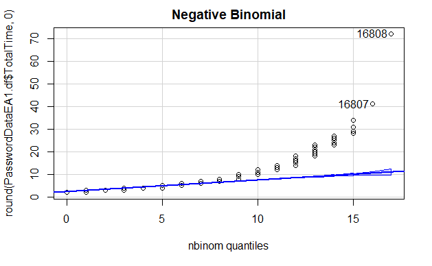

```r
# negative binomial
nbinom <- fitdistr(round(PasswordDataEA1.df$TotalTime,0), "Negative Binomial")
qqp(round(PasswordDataEA1.df$TotalTime,0), "nbinom", size = nbinom$estimate[[1]], mu = nbinom$estimate[[2]], main= "Negative Binomial")
```

```
[1] 16808 16807
```

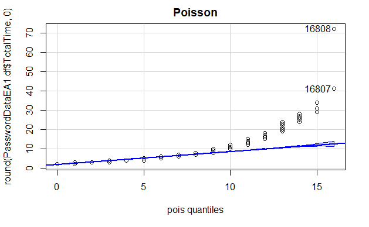

```r
# Poisson
poisson <- fitdistr(round(PasswordDataEA1.df$TotalTime,0), "Poisson")
qqp(round(PasswordDataEA1.df$TotalTime,0), "pois", lambda = poisson$estimate, main= "Poisson")
```

Next I utilized quantile comparison plots to check what probability distribution best fits the response variable. I tested with Normal, Lognormal, Gamma, Negative Binomial and Poisson. I decided to fit the dataset to a Gamma distribution as although Poisson seemed like a slightly closer fit, it also would require a transformation of the response variable from continuous to discrete, or in other words rounding to whole numbers.

## Statistical Analysis

```r
#Testing the models
#Random intercept models with a random effect term consisting of a slope and cluster term
#Gamma Distribution with Identity Link Function
PQL1 <- glmmPQL(TotalTime ~ sessionIndex + rep, ~1 | subject, family=Gamma(link=identity), data = PasswordDataEA1.df, verbose = FALSE)
summary(PQL1)
```

```
Linear mixed-effects model fit by maximum likelihood
  Data: PasswordDataEA1.df
```

|  | AIC | BIC | logLik |
| --- | --- | --- | --- |
|  | NA | NA | NA |

```
Random effects:
 Formula: ~1 | subject
        (Intercept)  Residual
StdDev:    1.681695 0.2156055

Variance function:
 Structure: fixed weights
 Formula: ~invwt
Fixed effects:  TotalTime ~ sessionIndex + rep
```

|  | Value | Std.Error | DF | t-value | p-value |
| --- | --- | --- | --- | --- | --- |
| (Intercept) | 6.080892 | 0.23638450 | 20347 | 25.72458 | 0 |
| sessionIndex | -0.186639 | 0.00293549 | 20347 | -63.58006 | 0 |
| rep | -0.007104 | 0.00046170 | 20347 | -15.38636 | 0 |

```
 Correlation:
             (Intr) sssnIn
sessionIndex -0.061
rep          -0.051 -0.006

Standardized Within-Group Residuals:
       Min         Q1        Med         Q3        Max
-2.0596331 -0.6027234 -0.2148257  0.3582809 26.8555520

Number of Observations: 20400
Number of Groups: 51
```

```r
#Gamma Distribution with Inverse Link Function
PQL2 <- glmmPQL(TotalTime ~ sessionIndex + rep, ~1 | subject, family=Gamma(link=inverse), data = PasswordDataEA1.df, verbose = FALSE)
summary(PQL2)
```

```
Linear mixed-effects model fit by maximum likelihood
  Data: PasswordDataEA1.df
```

|  | AIC | BIC | logLik |
| --- | --- | --- | --- |
|  | NA | NA | NA |

```
Random effects:
 Formula: ~1 | subject
        (Intercept)  Residual
StdDev:   0.0699077 0.4294586

Variance function:
 Structure: fixed weights
 Formula: ~invwt
Fixed effects:  TotalTime ~ sessionIndex + rep
```

|  | Value | Std.Error | DF | t-value | p-value |
| --- | --- | --- | --- | --- | --- |
| (Intercept) | 0.08132964 | 0.009851592 | 20347 | 8.25548 | 0 |
| sessionIndex | 0.02501722 | 0.000200294 | 20347 | 124.90233 | 0 |
| rep | 0.00130749 | 0.000011767 | 20347 | 111.11277 | 0 |

```
 Correlation:
             (Intr) sssnIn
sessionIndex -0.090
rep          -0.084  0.854

Standardized Within-Group Residuals:
         Min           Q1          Med           Q3          Max
-17.21917631  -0.50295919  -0.04113114   0.32990583   2.34407934

Number of Observations: 20400
Number of Groups: 51
```

```r
#Random Intercept and Slope models with random slope term for rep
#Gamma Distribution with Identity Link Function
PQL3 <- glmmPQL(TotalTime ~ sessionIndex + rep,~1+rep|subject, family=Gamma(link=identity), data = PasswordDataEA1.df, verbose = FALSE)
summary(PQL3)
```

```
Linear mixed-effects model fit by maximum likelihood
  Data: PasswordDataEA1.df
```

|  | AIC | BIC | logLik |
| --- | --- | --- | --- |
|  | NA | NA | NA |

```
Random effects:
 Formula: ~1 + rep | subject
 Structure: General positive-definite, Log-Cholesky parametrization
            StdDev     Corr
(Intercept) 1.95131724 (Intr)
rep         0.01173108 -0.904
Residual    0.21255575

Variance function:
 Structure: fixed weights
 Formula: ~invwt
Fixed effects:  TotalTime ~ sessionIndex + rep
```

|  | Value | Std.Error | DF | t-value | p-value |
| --- | --- | --- | --- | --- | --- |
| (Intercept) | 6.191267 | 0.27407585 | 20347 | 22.58961 | 0 |
| sessionIndex | -0.186821 | 0.00289161 | 20347 | -64.60783 | 0 |
| rep | -0.011385 | 0.00171970 | 20347 | -6.62033 | 0 |

```
 Correlation:
             (Intr) sssnIn
sessionIndex -0.052
rep          -0.875 -0.001

Standardized Within-Group Residuals:
       Min         Q1        Med         Q3        Max
-2.0665392 -0.6019761 -0.2115863  0.3536210 25.6716237

Number of Observations: 20400
Number of Groups: 51
```

```r
#Gamma Distribution with Inverse Link Function
PQL4 <- glmmPQL(TotalTime ~ sessionIndex + rep,~1+rep|subject, family=Gamma(link=inverse), data = PasswordDataEA1.df, verbose = FALSE)
summary(PQL4)$Value
```

[output not shown]

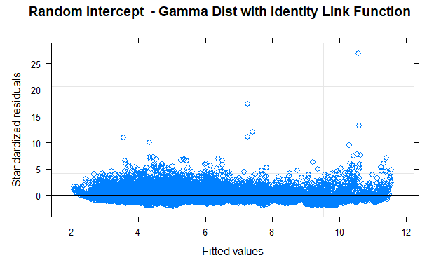

```r
#Plot the residuals to check which models best fit the data
plot(PQL1, main = "Random Intercept  - Gamma Dist with Identity Link Function")
```

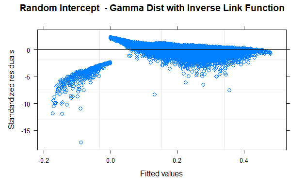

```r
plot(PQL2, main = "Random Intercept  - Gamma Dist with Inverse Link Function")
```

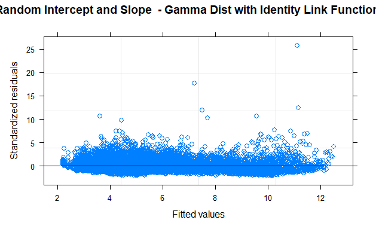

```r
plot(PQL3, main = "Random Intercept and Slope  - Gamma Dist with Identity Link Function")
```

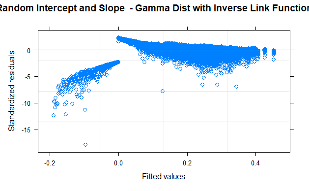

```r
plot(PQL4, main = "Random Intercept and Slope  - Gamma Dist with Inverse Link Function")
```

```r
#Results Table of final model results with a highlight on the chosen models
fixed.effect <- c('TotalTime ~ sessionIndex + rep','TotalTime ~ sessionIndex + rep','TotalTime ~ sessionIndex + rep','TotalTime ~ sessionIndex + rep')
random.effect <- c('1 | subject','1 | subject','1+rep|subject','1+rep|subject')
family <- c('Gamma(link=identity)','Gamma(link=inverse)','Gamma(link=identity)','Gamma(link=inverse)')
fixed.vars <- c('sessionIndex / rep', 'sessionIndex / rep', 'sessionIndex / rep', 'sessionIndex / rep')
coefficient.estimate <- c('-0.186639 / -0.007104', '0.02501722 / 0.00130749', '-0.186821    / -0.011385', '0.02638535 / 0.00050069')
std.error <- c('0.00293549 / 0.00046170','0.000200294 / 0.000011767','0.00289161 / 0.00171970','0.000222314 / 0.000086832')
t_value <- c('63.58006 /    -15.38636', '124.90233 / 111.11277','   -64.60783 / -6.62033','118.68508 / 5.76625')
p_value <- c('0 / 0', '0 / 0', '0 / 0', '0 / 0')
# Join the variables to create a data frame
df2 <- data.frame(fixed.effect,random.effect,family,fixed.vars,coefficient.estimate,std.error,t_value,p_value)

#Utilize datatable and formattable to highlight a row
datatable(df2) %>% formatStyle(
  'family',
  target = 'row',
  backgroundColor = styleEqual(c("Gamma(link=identity)"), c('lime'))
)
```

[output not shown]

```r
NA
NA
NA
```

The results of these two models show that repetitions and consecutive sessions do influence password typing speed. In fact, the p value obtained shows that the null hypothesis has not been disproven. Results show that total time taken to type the password decreases as repetitions increase and to a greater extent as session increases. In other words, people tend to type a password faster the more they type it in a given day and when repeatedly typing the password on consecutive days.

## Post Hoc Analysis

For the post hoc analysis, I decided to further confirm whether the response variable is not normally distributed and compare the fixed effects to determine if there’s an interaction between them. I tested this via a Shapiro-Wilkins test for normality grouped by subject as this test has a limit of 3500 for observations, and by manipulating the closest fitting model to have a fixed variable of session:repetition.

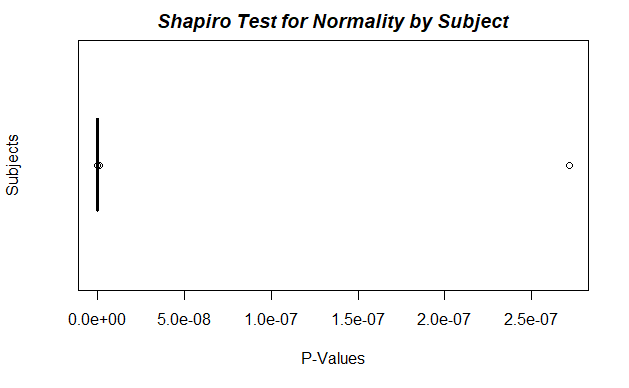

```r
# Run a Shapiro-Wilk test for normality on the dataset grouped by subject
ShapiroTestResults <- PasswordDataEA1.df %>%
  group_by(subject) %>%
  do(tidy(shapiro.test(.$TotalTime)))


#View the results in a boxplot to get an idea of where the data is centered at
boxplot(ShapiroTestResults$p.value, density = 20,
        legend.text = rownames(ShapiroTestResults$subject), horizontal = TRUE, xlab = "P-Values", ylab = "Subjects")
title(main = list("Shapiro Test for Normality by Subject", font = 4))
```

```r
#Check for an interaction term between sessionIndex and rep
posthocPQL1 <- glmmPQL(TotalTime ~ sessionIndex*rep + sessionIndex +rep, ~1 | subject, family=Gamma(link=identity), data = PasswordDataEA1.df, verbose = FALSE)

#View Results
summary(posthocPQL1)
```

```
Linear mixed-effects model fit by maximum likelihood
  Data: PasswordDataEA1.df
```

|  | AIC | BIC | logLik |
| --- | --- | --- | --- |
|  | NA | NA | NA |

```
Random effects:
 Formula: ~1 | subject
        (Intercept)  Residual
StdDev:      1.6813 0.2132885

Variance function:
 Structure: fixed weights
 Formula: ~invwt
Fixed effects:  TotalTime ~ sessionIndex * rep + sessionIndex + rep
```

|  | Value | Std.Error | DF | t-value | p-value |
| --- | --- | --- | --- | --- | --- |
| (Intercept) | 6.487096 | 0.23783764 | 20346 | 27.27531 | 0 |
| sessionIndex | -0.268579 | 0.00602308 | 20346 | -44.59160 | 0 |
| rep | -0.022724 | 0.00109991 | 20346 | -20.66014 | 0 |
| sessionIndex:rep | 0.003146 | 0.00020085 | 20346 | 15.66136 | 0 |

```
 Correlation:
                 (Intr) sssnIn rep
sessionIndex     -0.128
rep              -0.124  0.806
sessionIndex:rep  0.112 -0.876 -0.910

Standardized Within-Group Residuals:
       Min         Q1        Med         Q3        Max
-2.0340800 -0.6005026 -0.2080043  0.3603056 26.5097010

Number of Observations: 20400
Number of Groups: 51
```

```r
#Set up a formatted table for the results
fixed.effect <- c('TotalTime ~ sessionIndex*rep + sessionIndex + rep','TotalTime ~ sessionIndex*rep + sessionIndex + rep','TotalTime ~ sessionIndex*rep + sessionIndex + rep')
random.effect <- c('1 | subject','1 | subject','1 | subject')
family <- c('Gamma(link=identity)','Gamma(link=identity)','Gamma(link=identity)')
fixed.vars <- c('sessionIndex','rep','sessionIndex:rep')
value <- c('-0.268579', '-0.022724', '0.003146')
std.error <- c('0.00602308', '0.00109991', '0.00020085')
t_value <- c('-44.59160','-20.66014','15.66136')
p_value <- c('0','0','0')
# Join the variables to create a data frame
df2 <- data.frame(fixed.effect,random.effect,family,fixed.vars,value,std.error,t_value,p_value)
#Highlight relevant row
datatable(df2) %>% formatStyle(
  'fixed.vars',
  target = 'row',
  backgroundColor = styleEqual(c("sessionIndex:rep"), c('lime'))
)
```

|  | fixed.effect | random.effect | family | fixed.vars | value | std.error | t_value | p_value |
| --- | --- | --- | --- | --- | --- | --- | --- | --- |
| 1 | TotalTime ~ sessionIndex*rep + sessionIndex + rep | 1 \| subject | Gamma(link=identity) | sessionIndex | -0.268579 | 0.00602308 | -44.59160 | 0 |
| 2 | TotalTime ~ sessionIndex*rep + sessionIndex + rep | 1 \| subject | Gamma(link=identity) | rep | -0.022724 | 0.00109991 | -20.66014 | 0 |
| 3 | TotalTime ~ sessionIndex*rep + sessionIndex + rep | 1 \| subject | Gamma(link=identity) | sessionIndex:rep | 0.003146 | 0.00020085 | 15.66136 | 0 |

```r
NA
NA
NA
NA
```

The results of my post-hoc analysis were that the data is definitely not of a normal distribution and that there is an interaction between session and repetition although it has a very small effect on the response variable compared to that of session and repetition individually.

## Conclusions

The random effects model I created that fits the data the best indicates that the time taken to type a password, changes over time as one retypes it throughout the day and on consecutive days. Thus, I’ve failed to reject the null hypothesis and I have confirmed that at least within the boundaries of this sample and to a statistically significant extent, a person’s typing dynamics change over time, short and long term. Also, the results of the post-hoc analysis showed that the data is extremely likely to not be normally distributed and that there is an interaction between session and repetition.